# Normal test

Redkokosh Kirilll

12/23/2021

```r
library(dplyr)
library(lattice)
library(tidyr)
library(GGally)
library(ggpubr)
```

```r
df <- read.csv("table1.csv", header = TRUE, as.is = FALSE, sep = ';')
head(df)
```

```
##         Имя      Фамилия Вид.записи Структурное.подразделение курс б.с.м
## 1     Элина        Абляз         пз                      ЕИСН    4     б
## 2    Зарина   Аблямитова         пз                      ИПОМ    4     б
## 3   Татьяна     Авдиенко         сз                      АСиА    1     м
## 4 Гюльбахар Амирасланова         пз                      ИПОМ    3     б
## 5 Александр      Андреев         сз                       ФТИ    4     б
## 6    Ленура     Арабская         сз                       ФТИ    1     м
##   ТЦК_binary ТЦК_балл Уровень.сформированности СЦК_старт   Т1  Т2 Т3   Т4   Т5
## 1          1       67              продвинутый      8.00 0.57 0.6  1 0.33 0.47
## 2          1       26                начальный        NA 1.00 1.0  1 1.00 1.00
## 3          1       75                  высокий      8.67 1.00 1.0  1 1.00 1.00
## 4          1       49                  базовый     10.67 1.00 1.0  1 1.00 1.00
## 5          1       77                  высокий      5.00 0.86 0.8  1 1.00 0.81
## 6          1       80                  высокий     11.67 0.86 0.8  1 1.00 1.00
##   П2 Т6   Т7   Т8   Т9  Т10  Т11 П4 П5 П6 П8 П9 СЦК_финал ИТ_В1 ИТ_В2 ИТ_В3
## 1  2  1 0.67 0.42 0.67 0.50 0.83 NA NA NA NA NA     12.00 13.17    NA    NA
## 2  4  1 1.00 1.00 1.00 1.00 1.00  3  6  7 NA  2     10.33 15.83 22.83 14.53
## 3  8  1 1.00 1.00 1.00 1.00 1.00  6  8 NA NA NA     11.67 24.33    NA    NA
## 4  4  1 1.00 1.00 1.00 1.00 1.00 NA NA NA NA NA        NA 14.33  7.10    NA
## 5 NA  1 1.00 1.00 0.81 0.92 1.00 NA NA NA NA NA      9.00 21.50    NA    NA
## 6  7  1 1.00 1.00 1.00 1.00 1.00  6  7  8  4  5        NA 20.83    NA    NA
##   ИТ_max П1 П3 П7 П1.П3.П7 Уровень.сформированности..ИТ. ТБ_база ТБ_.доп  ИТОГ
## 1  13.17 NA NA NA        0                       базовый     9.6     9.6 22.23
## 2  22.83 NA  5  5       10                       высокий    33.0    43.0 65.83
## 3  24.33  5  5  4       14                       высокий    33.0    47.0 71.33
## 4  14.33  3  3 NA        6                       базовый    15.0    21.0 35.33
## 5  21.50 NA NA NA        0                   продвинутый    10.2    10.2 31.70
## 6  20.83 NA NA NA        0                   продвинутый    46.8    46.8 67.63
```

```r
`%!in%` <- Negate(`%in%`)
df$ИТ_max <- (10/3)*df$ИТ_max
df <- df %>% mutate(group = ifelse( (б.с.м %in% "б"), ifelse( (курс %!in% 4) , "1", "2"), "2"))
df$group <- as.factor(df$group)
```

```r
group1 <- subset(df, group == 1)
group2 <- subset(df, group == 2)
```

Количество людей в каждой группе, если больше 30 человек в группе, то можно говорить об асимптотической сходимости методов:

```r
nrow(group1)
```

```
## [1] 93
```

```r
nrow(group2)
```

```
## [1] 84
```

Среднее по группам:

```r
mean(group1$ТЦК_балл)
```

```
## [1] 67.13978
```

```r
mean(group2$ТЦК_балл)
```

```
## [1] 62.94048
```

```r
median(group1$ТЦК_балл)
```

```
## [1] 69
```

```r
median(group2$ТЦК_балл)
```

```
## [1] 66.5
```

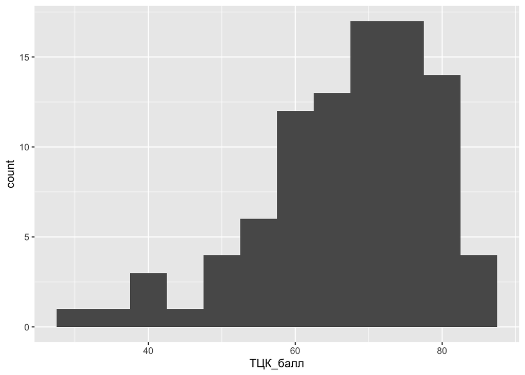

```r
ggplot(data = group1, aes(x = ТЦК_балл)) +
  geom_histogram(binwidth = 5)
```

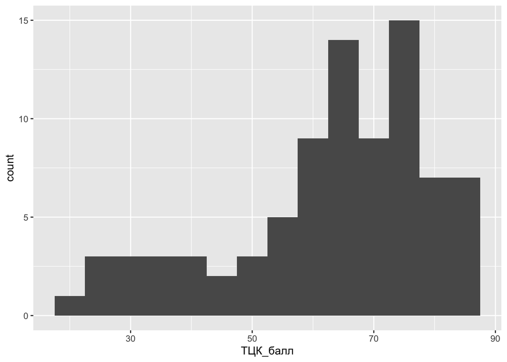

```r
ggplot(data = group2, aes(x = ТЦК_балл)) +
  geom_histogram(binwidth = 5)
```

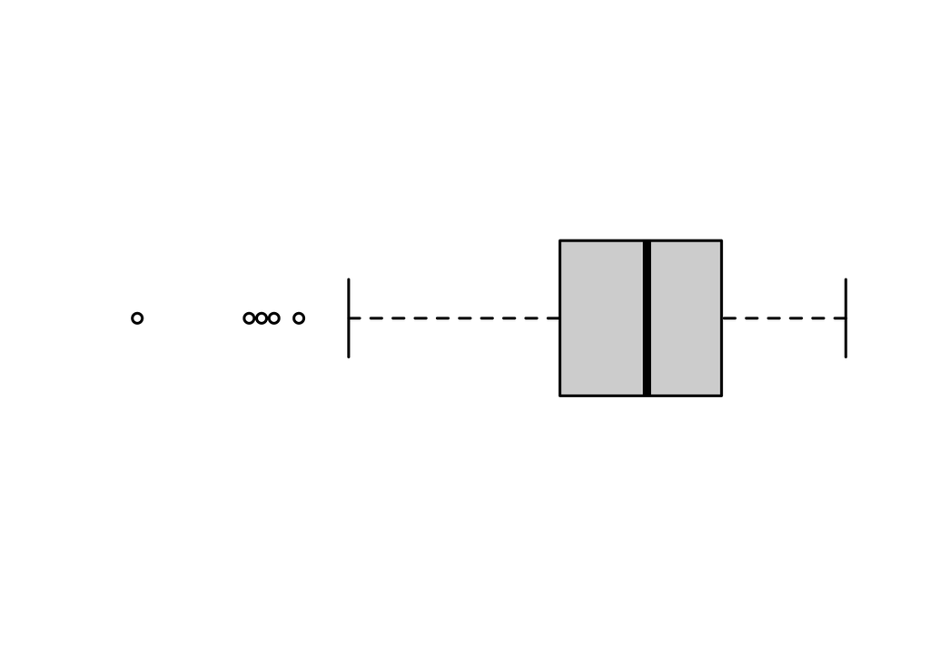

```r
boxplot(group1$ТЦК_балл, horizontal = TRUE, axes = FALSE,
        lwd = 2, col = rgb(0, 0, 0, alpha = 0.2))
```

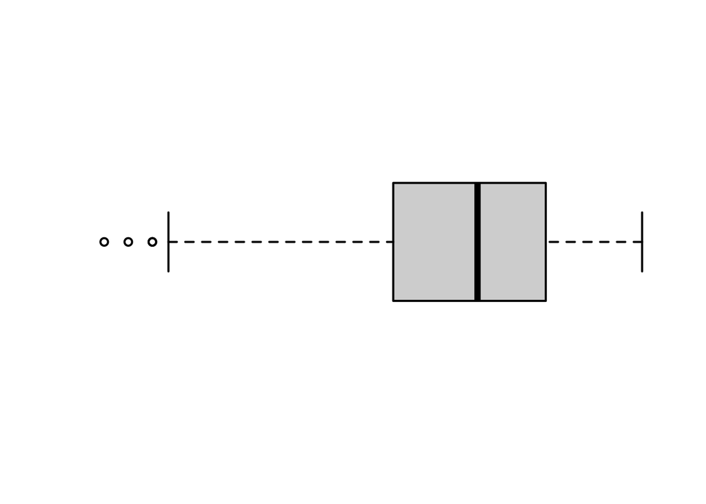

```r
boxplot(group2$ТЦК_балл, horizontal = TRUE, axes = FALSE,
        lwd = 2, col = rgb(0, 0, 0, alpha = 0.2))
```

Стандартные отклонения (а соответсвенно и дисперсии) визуально совсем разные.

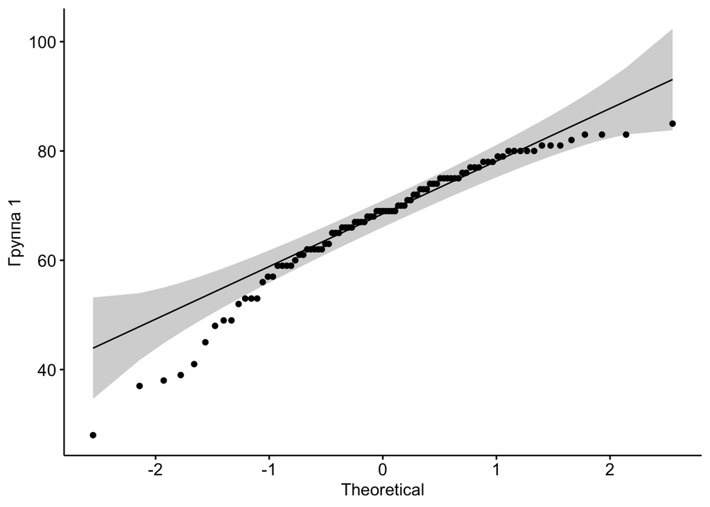

```r
ggqqplot(group1$ТЦК_балл, ylab = "Группа 1")
```

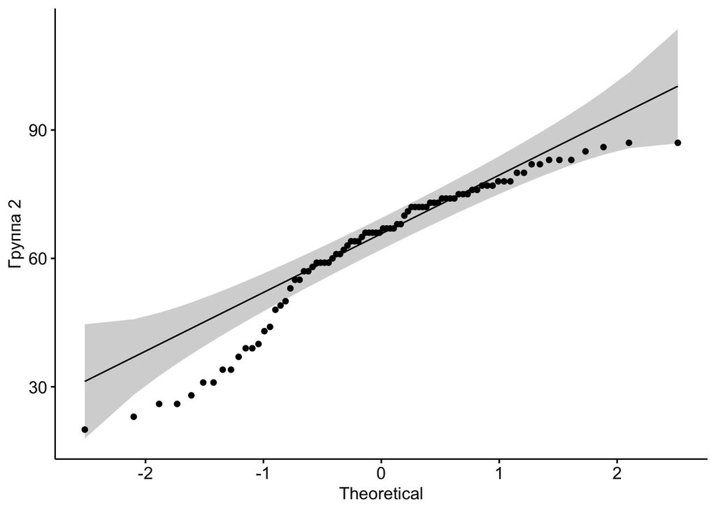

```r
ggqqplot(group2$ТЦК_балл, ylab = "Группа 2")
```

```r
shapiro.test(group1$ТЦК_балл)$p.value
```

```
## [1] 0.0001202907
```

```r
shapiro.test(group2$ТЦК_балл)$p.value
```

```
## [1] 4.340197e-05
```

Присутствуют единичные outliers (важно- с одной стороны), а также выборки не из нормального распределения (но присутствует асимптотическая сходимость), так что лучше использовать критерий Манна-Уитни (wilcox.test). Вообще говоря в этом случае эти два теста проверяют разные гипотезы.

```r
wilcox.test(group1$ТЦК_балл, group2$ТЦК_балл)
```

```
##
##  Wilcoxon rank sum test with continuity correction
##
## data:  group1$ТЦК_балл and group2$ТЦК_балл
## W = 4350.5, p-value = 0.1919
## alternative hypothesis: true location shift is not equal to 0
```

```r
#t.test(group1$ТЦК_балл, group2$ТЦК_балл)$p.value
```

p-value > 0.05 значит мы не отвергаем гипотезу о равенстве медиан.

```r
sd(group1$ТЦК_балл)
```

```
## [1] 11.67456
```

```r
sd(group2$ТЦК_балл)
```

```
## [1] 16.79885
```

Какие-то огромные выборочные стандартные отклонения, но самое главное, что они очень отличаются.

```r
bartlett.test(ТЦК_балл ~ group, df)
```

```
##
##  Bartlett test of homogeneity of variances
##
## data:  ТЦК_балл by group
## Bartlett's K-squared = 11.383, df = 1, p-value = 0.000741
```

```r
var.test(ТЦК_балл ~ group, df)
```

```
##
##  F test to compare two variances
##
## data:  ТЦК_балл by group
## F = 0.48297, num df = 92, denom df = 83, p-value = 0.000731
## alternative hypothesis: true ratio of variances is not equal to 1
## 95 percent confidence interval:
##  0.3158499 0.7351034
## sample estimates:
## ratio of variances
##          0.4829726
```

Оба теста говорят, что дисперсии не равны.

```r
group1 <- group1 %>% mutate(group11 = ifelse( (ТЦК_балл > 60), ifelse( (ТЦК_балл > 74) , "3", "2"), "1"))
group1$group11 <- as.factor(group1$group11)
group2 <- group2 %>% mutate(group21 = ifelse( (ТЦК_балл > 60), ifelse( (ТЦК_балл > 74) , "3", "2"), "1"))
group2$group21 <- as.factor(group2$group21)
mice <- matrix(c(nrow(filter(group1, group11 == '1')), nrow(filter(group1, group11 == '2')), nrow(filter(group1, group11 == '3')), nrow(filter(group2, group21 == '1')), nrow(filter(group2, group21 == '2')), nrow(filter(group2, group21 == '3'))), nrow = 2, byrow = TRUE)
mice
```

```
##      [,1] [,2] [,3]
## [1,]   21   43   29
## [2,]   29   33   22
```

```r
chisq.test(mice)
```

```
##
##  Pearson's Chi-squared test
##
## data:  mice
## X-squared = 3.107, df = 2, p-value = 0.2115
```

Согласно критерию хи-квадрат мы не отвергаем гипотезу о равенстве распределений.

Дальше про итоговый тест:

```r
group1$ИТ_max <- as.double(group1$ИТ_max)
group2$ИТ_max <- as.double(group2$ИТ_max)
```

Среднее по группам:

```r
mean(group1$ИТ_max)
```

```
## [1] 68.71147
```

```r
mean(group2$ИТ_max)
```

```
## [1] 67.23135
```

```r
median(group1$ИТ_max)
```

```
## [1] 68.9
```

```r
median(group2$ИТ_max)
```

```
## [1] 69.43333
```

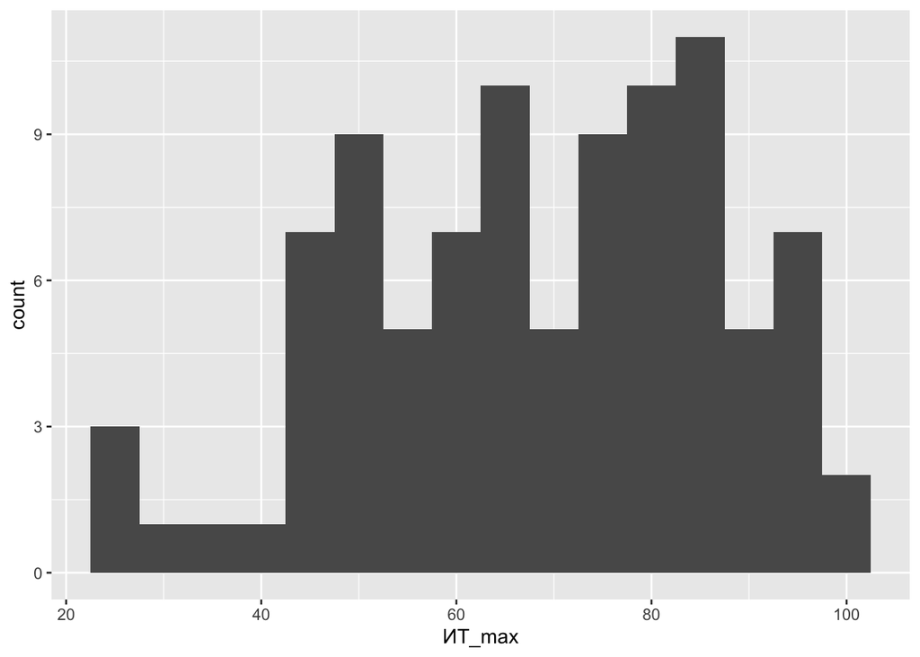

```r
ggplot(data = group1, aes(x = ИТ_max)) +
  geom_histogram(binwidth = 5)
```

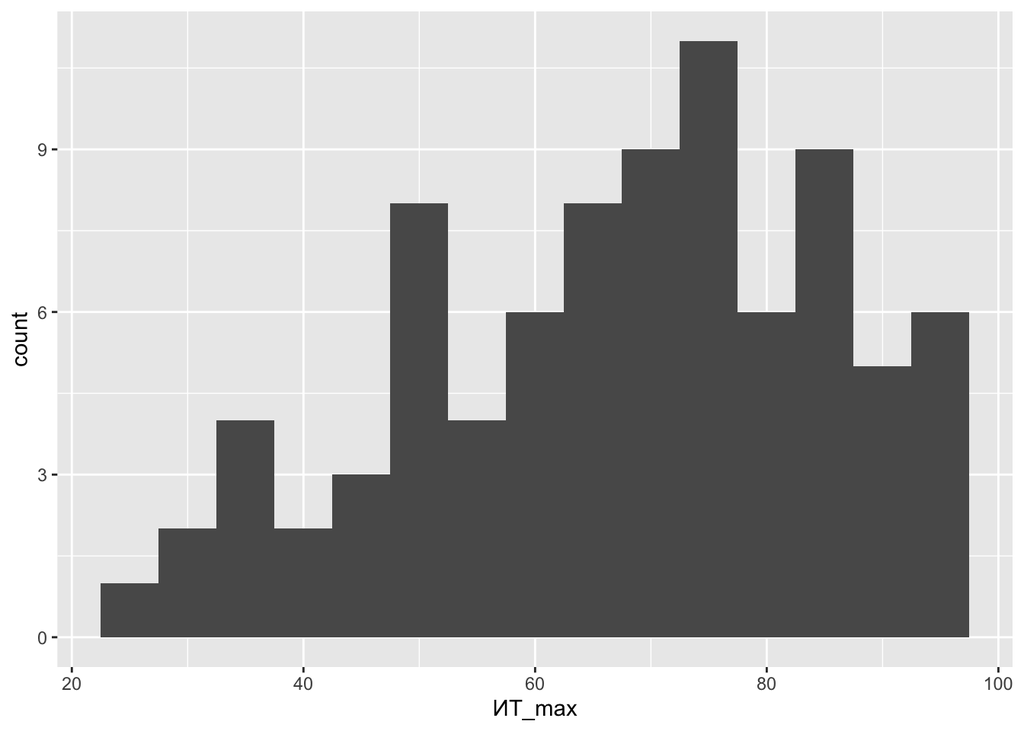

```r
ggplot(data = group2, aes(x = ИТ_max)) +
  geom_histogram(binwidth = 5)
```

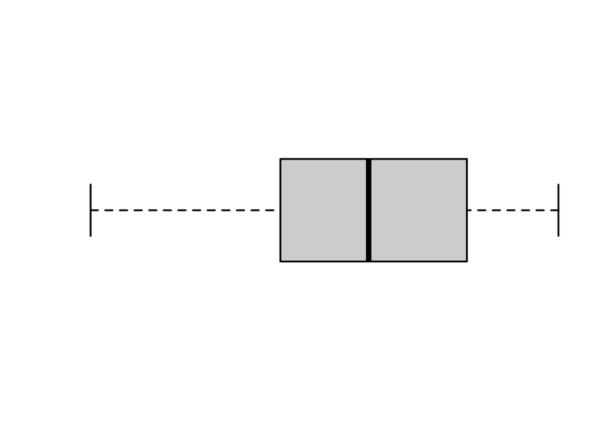

```r
boxplot(group1$ИТ_max, horizontal = TRUE, axes = FALSE,
        lwd = 2, col = rgb(0, 0, 0, alpha = 0.2))
```

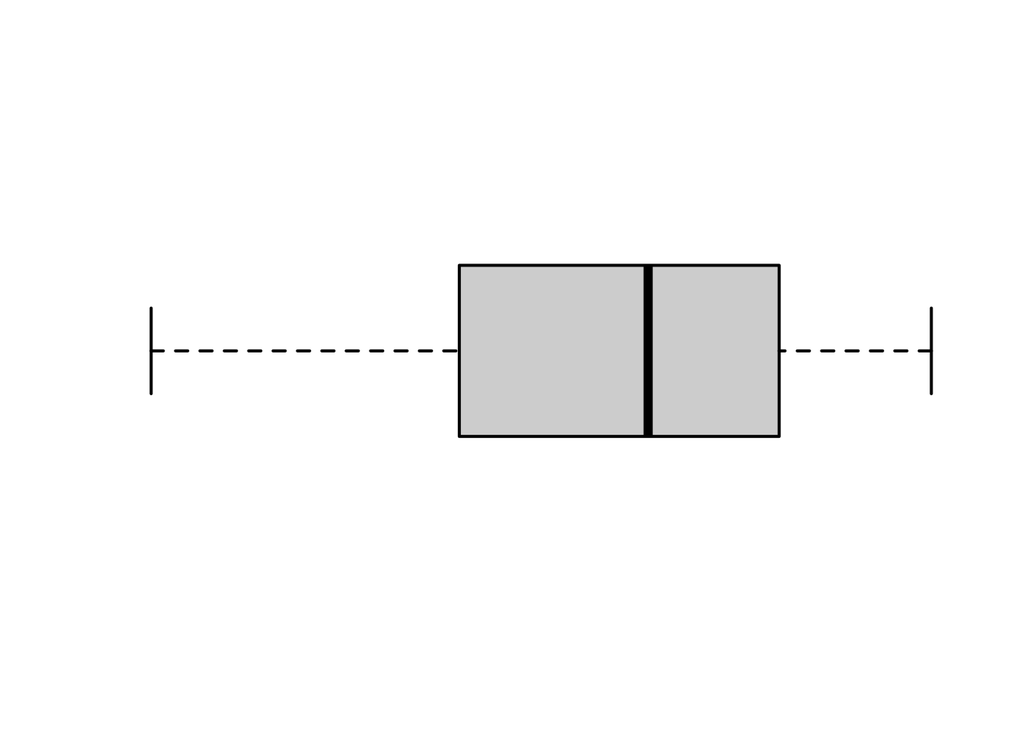

```r
boxplot(group2$ИТ_max, horizontal = TRUE, axes = FALSE,
        lwd = 2, col = rgb(0, 0, 0, alpha = 0.2))
```

Стандартные отклонения (а соответсвенно и дисперсии) визуально похожи.

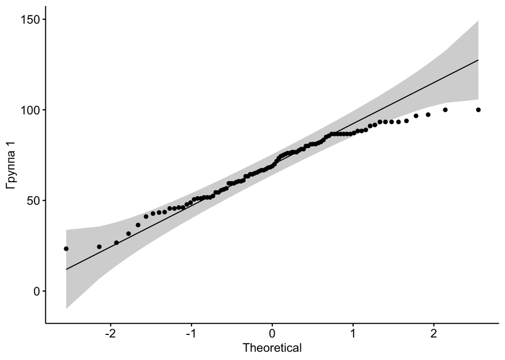

```r
ggqqplot(group1$ИТ_max, ylab = "Группа 1")
```

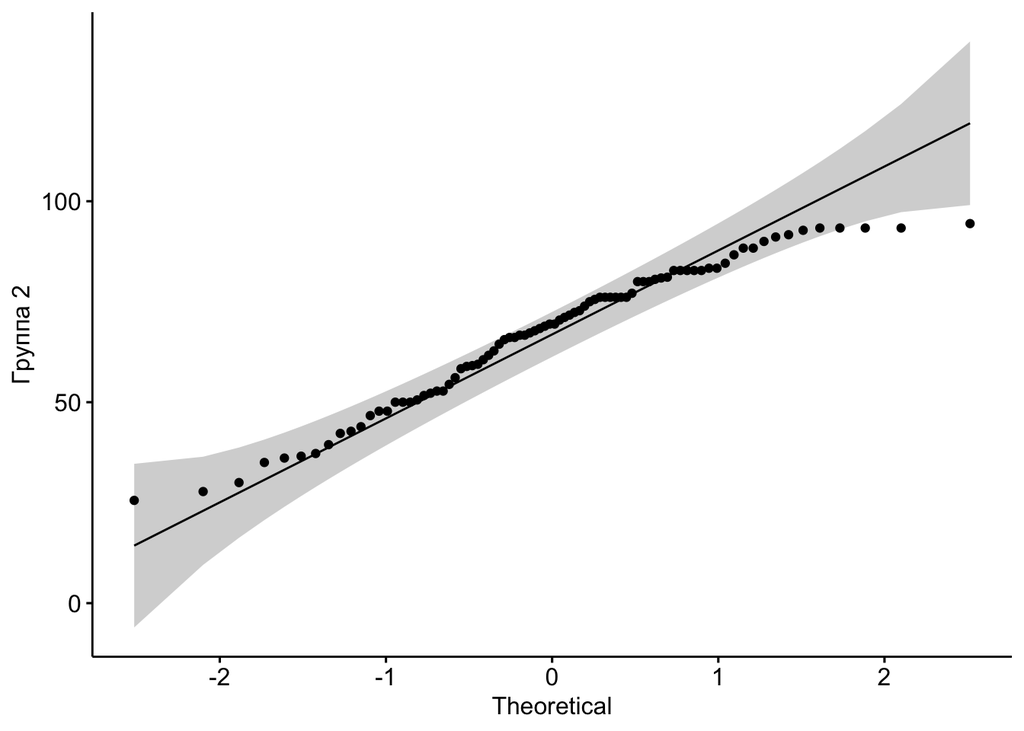

```r
ggqqplot(group2$ИТ_max, ylab = "Группа 2")
```

```r
shapiro.test(group1$ИТ_max)$p.value
```

```
## [1] 0.02531587
```

```r
shapiro.test(group2$ИТ_max)$p.value
```

```
## [1] 0.01089891
```

Выборки не из нормального распределения (но присутствует асимптотическая сходимость), но хотя бы выбросов нет, уже использовали критерий Манна-Уитни (wilcox.test), но тут можно было бы и t-test.

```r
wilcox.test(group1$ИТ_max, group2$ИТ_max)$p.value
```

```
## [1] 0.5666732
```

```r
t.test(group1$ИТ_max, group2$ИТ_max)$p.value
```

```
## [1] 0.5870924
```

p-value > 0.05 значит мы не отвергаем гипотезу о равенстве медиан (распредления достаточно симметричны, так что медиана ≈ среднему).

```r
sd(group1$ИТ_max)
```

```
## [1] 18.48747
```

```r
sd(group2$ИТ_max)
```

```
## [1] 17.69121
```

Тут и отличия не такие сильные.

```r
bartlett.test(ИТ_max ~ group, df)
```

```
##
##  Bartlett test of homogeneity of variances
##
## data:  ИТ_max by group
## Bartlett's K-squared = 0.16788, df = 1, p-value = 0.682
```

```r
var.test(ИТ_max ~ group, df)
```

```
##
##  F test to compare two variances
##
## data:  ИТ_max by group
## F = 1.092, num df = 92, denom df = 83, p-value = 0.6847
## alternative hypothesis: true ratio of variances is not equal to 1
## 95 percent confidence interval:
##  0.7141645 1.6621335
## sample estimates:
## ratio of variances
##           1.092044
```

Оба теста говорят, что мы не отвергаем гипотезу о равентсве дисперсий.

```r
group1 <- group1 %>% mutate(group11 = ifelse( (ИТ_max > 60), ifelse( (ИТ_max > 74) , "3", "2"), "1"))
group1$group11 <- as.factor(group1$group11)
group2 <- group2 %>% mutate(group21 = ifelse( (ИТ_max > 60), ifelse( (ИТ_max > 74) , "3", "2"), "1"))
group2$group21 <- as.factor(group2$group21)
mice <- matrix(c(nrow(filter(group1, group11 == '1')), nrow(filter(group1, group11 == '2')), nrow(filter(group1, group11 == '3')), nrow(filter(group2, group21 == '1')), nrow(filter(group2, group21 == '2')), nrow(filter(group2, group21 == '3'))), nrow = 2, byrow = TRUE)
mice
```

```
##      [,1] [,2] [,3]
## [1,]   30   20   43
## [2,]   28   21   35
```

```r
chisq.test(mice)
```

```
##
##  Pearson's Chi-squared test
##
## data:  mice
## X-squared = 0.45742, df = 2, p-value = 0.7956
```

Согласно критерию хи-квадрат мы не отвергаем гипотезу о равенстве распределений.

И для ТЦК и для итоговых оценок мы не отвергаем гипотезу о равенстве распределений, поэтому можно назвать выборки однородными.